### Assignment 03

### AS2018414

# Covid-19 in Armenia

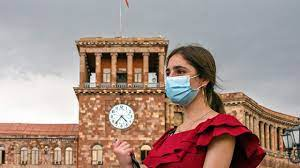

# Introduction

The first case of Covid-19 in Armenia was discovered on March 1, 2020.The patient was a 29-year-old citizen of Armenia, who arrived from Tehran. Initially the spread was slow,reaching 100 cases by March 17. The spread of the virus accelerated rapidly thereafter, reaching 1,000cases by April 10, 5000 cases by May 19 and 10,000 cases by June 2.1The growth in the number of deaths from the disease followed a similar patter, albeit at a lower level and with a time lag. The 100 deaths mark was reached on May 14 and by June 15 some 269 deaths had been registered. Over the past month (mid-May to mid-June) the number of infections doubled every two weeks and there are as yet (end-June) few signs of a slowdown.

#### Armenia vaccination

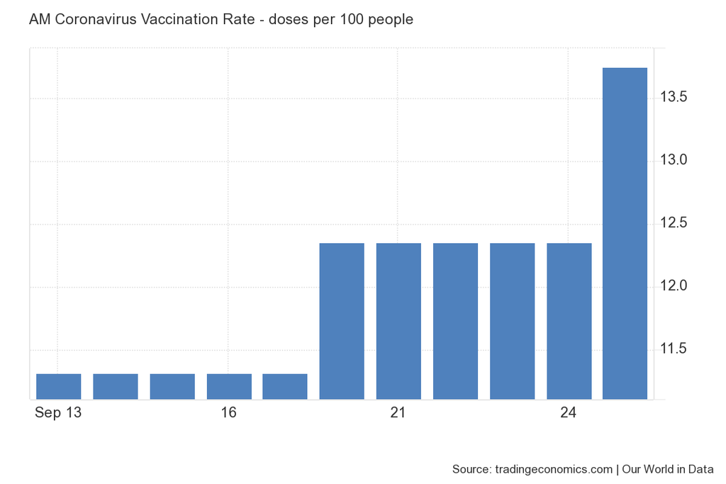

### Location of Armenia

[output not shown]

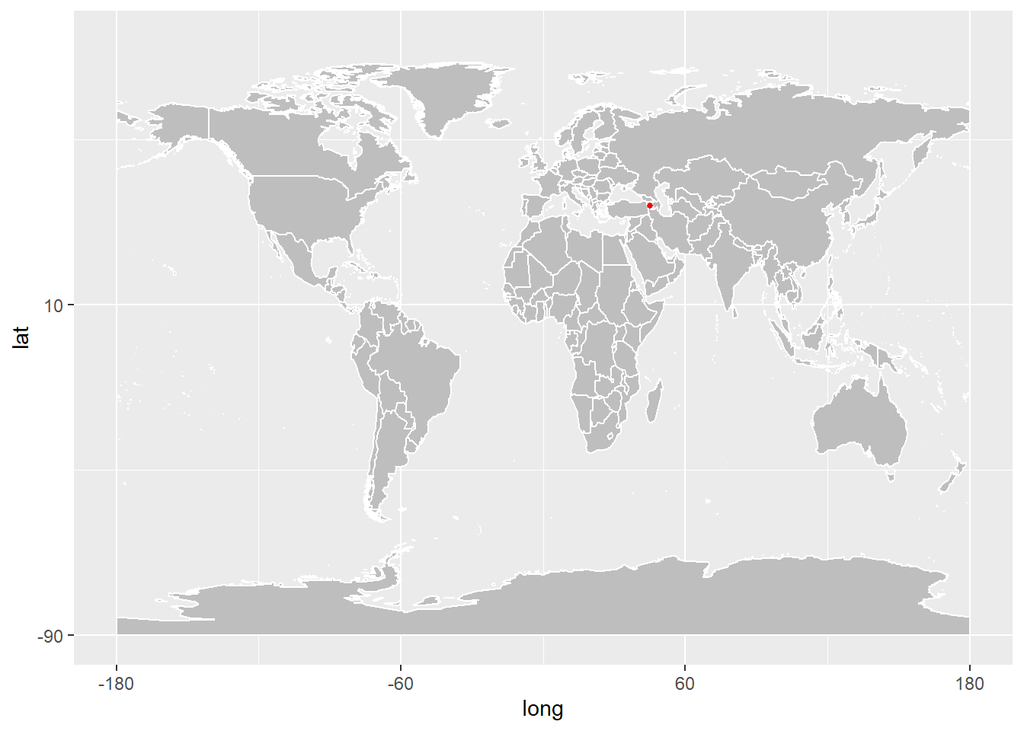

#### Neighboring countries

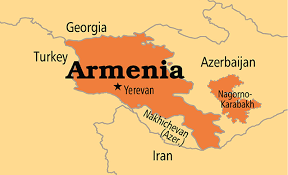

### Climate condition of Armenia

In Armenia, the climate is continental, with cold winters and hot summers.The climate becomes colder and wetter (and snowy in winter as well) with increasing altitude, while at lower elevations, the rains are scarce and the summer is very hot. In winter, cold air masses predominate, and after having reached the country from the north, they tend to stagnate in the valleys, causing severe frosts. Spring is an unstable season and experiences the most frequent rains, though they generally remain not abundant because, as mentioned, this country is generally arid, at least at lower elevations. Summer is dry and sunny, but with some afternoon thunderstorms in the mountains.From the mountains, a down-slope wind, dry and warm, similar to the Föhn or Chinook, can reach the valleys, especially in winter, but also in spring and autumn.

### Lockdown status in Armenia

Armenia confirmed its first Covid-19 case on March 1. On March 16, the government declared a state of emergency and extended it five times, ending it on September 11.In September, the government replaced the state of emergency with a special regime until January 11, which allows the national government to impose national or local lockdowns, and restrictions on gatherings and protests, without announcing a state of emergency.

### Action taken by the government

some of the key actions in January and February were the formation of a special Task Force to prevent the spread of the virus, temporary suspension of the visa-free regime with China, where the virus originated (just two weeks after a bilateral agreement between Armenia and China removing visa restrictions came into force) and closure of the border on February 23 with neighboring Iran. The messaging of the Government in early March, before a national lockdown and restrictions on freedom of movement were imposed, mainly focused on urging citizens to limit non-essential travel to countries where the virus was rapidly spreading.

## Data analysis

### data cleaning

```
        date country     lat    long      type cases   Month
1 2020-01-22 Armenia 40.0691 45.0382 confirmed     0 January
2 2020-01-23 Armenia 40.0691 45.0382 confirmed     0 January
3 2020-01-24 Armenia 40.0691 45.0382 confirmed     0 January
4 2020-01-25 Armenia 40.0691 45.0382 confirmed     0 January
5 2020-01-26 Armenia 40.0691 45.0382 confirmed     0 January
6 2020-01-27 Armenia 40.0691 45.0382 confirmed     0 January
```

```
           date country     lat    long      type cases  Month
1768 2021-07-30 Armenia 40.0691 45.0382 recovered   199   July
1769 2021-07-31 Armenia 40.0691 45.0382 recovered   163   July
1770 2021-08-01 Armenia 40.0691 45.0382 recovered   122 August
1771 2021-08-02 Armenia 40.0691 45.0382 recovered   147 August
1772 2021-08-03 Armenia 40.0691 45.0382 recovered   156 August
1773 2021-08-04 Armenia 40.0691 45.0382 recovered   149 August
```

```
      date              country               lat             long
 Min.   :2020-01-22   Length:1773        Min.   :40.07   Min.   :45.04
 1st Qu.:2020-06-17   Class :character   1st Qu.:40.07   1st Qu.:45.04
 Median :2020-11-12   Mode  :character   Median :40.07   Median :45.04
 Mean   :2020-11-12                      Mean   :40.07   Mean   :45.04
 3rd Qu.:2021-04-09                      3rd Qu.:40.07   3rd Qu.:45.04
 Max.   :2021-09-18                      Max.   :40.07   Max.   :45.04
     type               cases         Month
 Length:1773        Min.   :   0   Length:1773
 Class :character   1st Qu.:   6   Class :character
 Mode  :character   Median :  75   Mode  :character
                    Mean   : 270
                    3rd Qu.: 356
                    Max.   :8319
```

### Exploratory data analysis

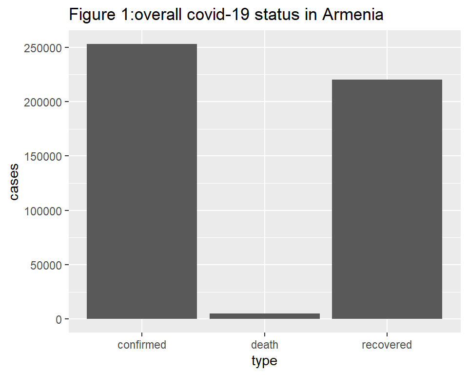

According to that figure 1 there were all confirmed cases are more than 250000 and the death cases are low value until August 04,2021.

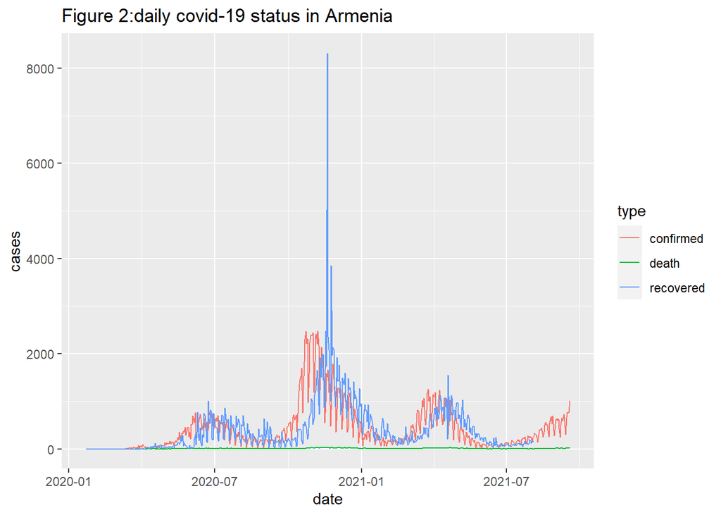

By the figure2, we can see number of corona virus patients started increasing slowly,but end of the 2020 that is increased to daily confirmed cases were more than 2000 and again it went to down. The recovered cases as like as the confirmed cases.In the end of the 2020 that is increased highly. Daily reported death cases are constant.

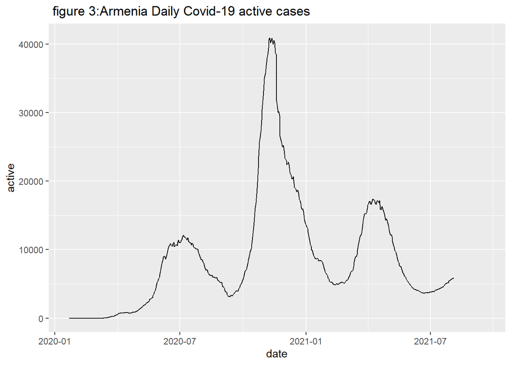

According to the figure 3 the daily active cases increased in the end of the 2020. That is more than 40000. After the January 2021 it has been to maintain the active cases of less than 20000.

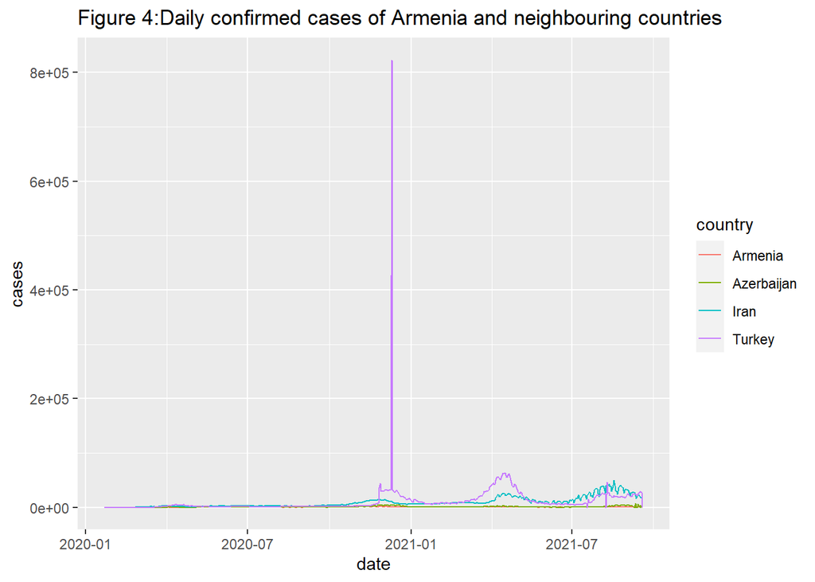

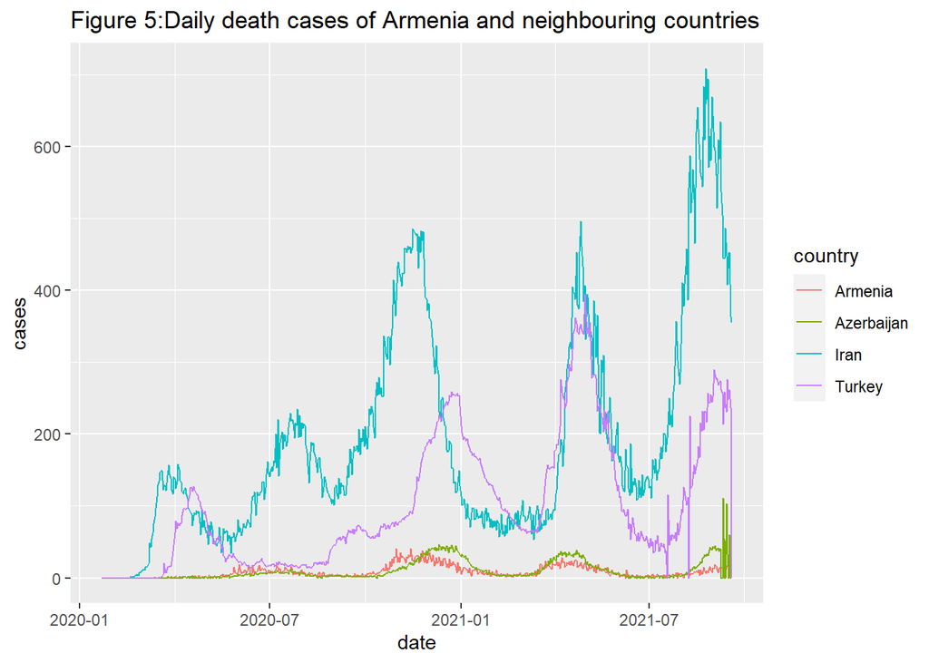

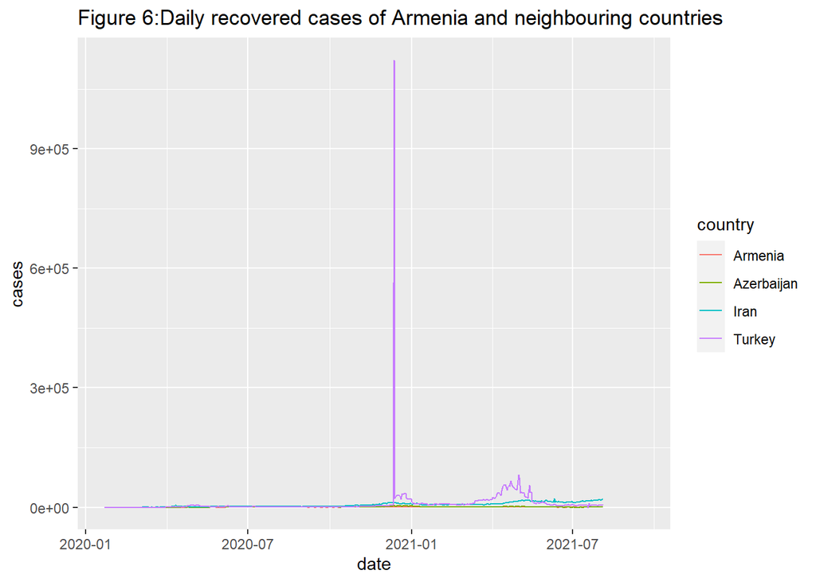

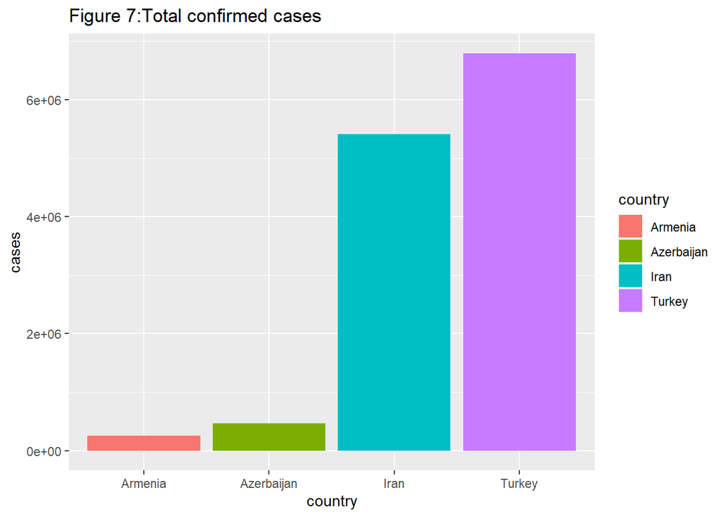

By the figure 7, we can see total covid-19 confirmed cases were recorded. Here Turkey has the highest total value of the confirmed cases and Armenia has the lowest value.

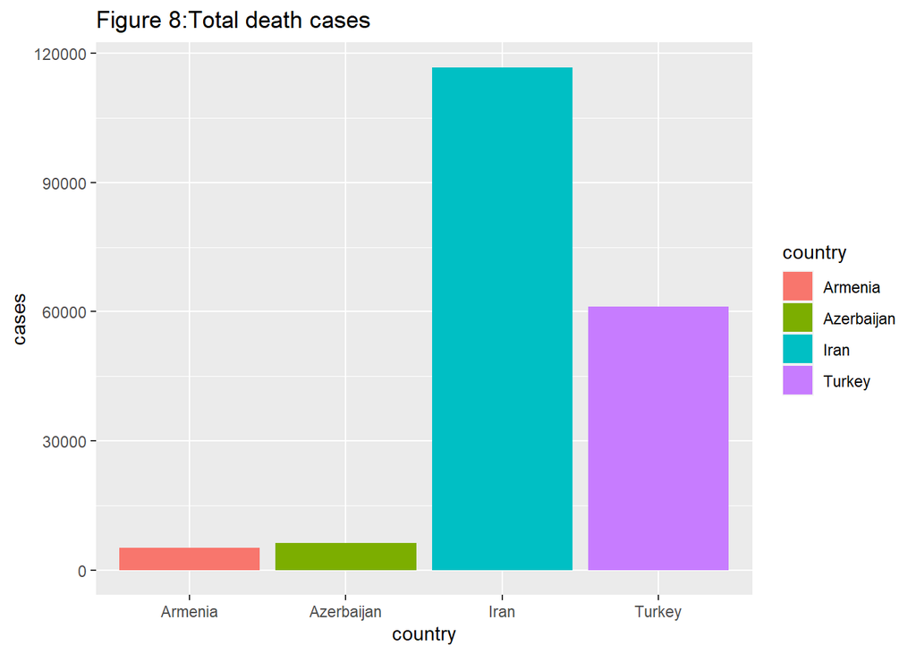

According to the figure 8 the highest death cases are reported in Iran. Armenia has the lowest value.

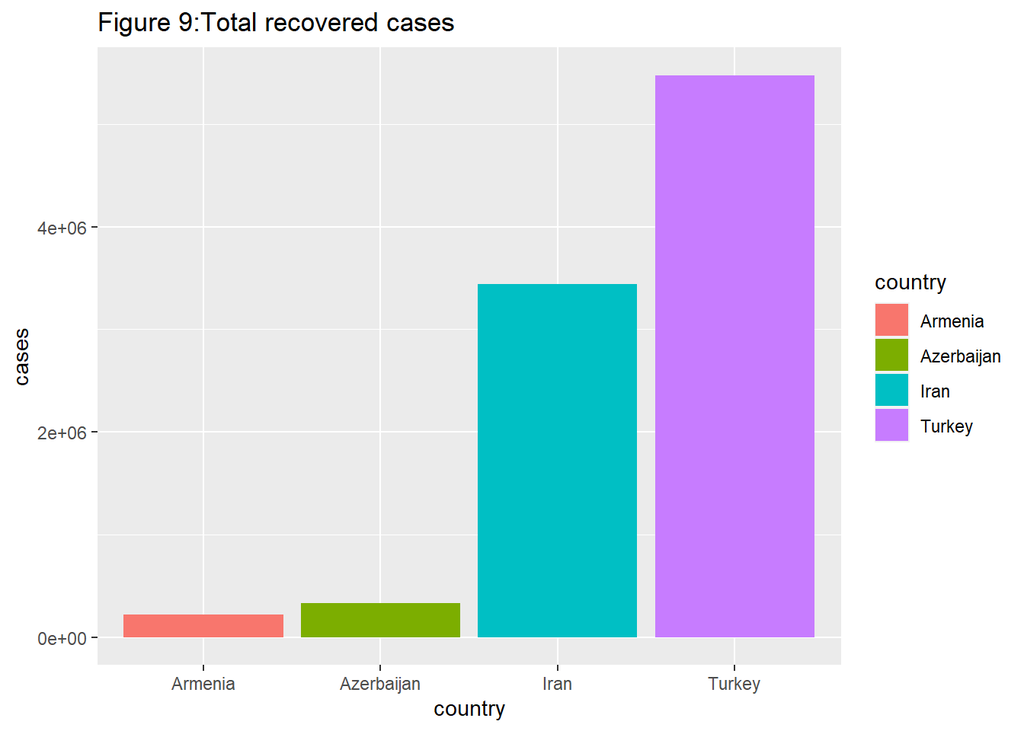